# Music Chart Analysis

In this project, I analyze trends in the Billboard Hot 100 music charts over the last 61 years, and integrate data from Spotify’s API to make predictions about songs on the charts.

SPOTIFY API In this chunk, I create three functions which I use throughout my code to make calls to Spotify’s API. The first, spotifyAPI(), takes in a URL meant to be an “endpoint” in Spotify’s API, which will return data in a JSON format. The second, getTrackIDFromQuery(), takes in a character query and searches for it through Spotify’s API, then returns the first track ID found in the results. I use this to get the spotify track IDs of songs on the Billboard charts by entering the track title and the artist’s name as query parameters. The final function takes a spotify track id and returns a JSON containing data describing the audio features of that track. This includes many descriptors of the content of the track itself. More can be found at https://developer.spotify.com/console/get-audio-features-track/.

```r
library(jsonlite)
library(httr)
library(dplyr)
library(rvest)
clientID <- "f37c56713eee4eb390b4fa3d0b963ffd"
secret <- "3488df63939040ff8d4715a694c60fbd"

accessToken <- content(POST(
  "https://accounts.spotify.com/api/token",
  accept_json(),
  authenticate(clientID, secret),
  body = list(grant_type = "client_credentials"),
  encode = "form",
  verbose()
))$access_token
```

```r
authentication <- paste0("Bearer ", accessToken)

spotifyAPI <- function(URL) {
  return(GET(url = URL, add_headers(Authorization = authentication)))
}

getTrackIDFromQuery <- function(query) {
  return(fromJSON(content(spotifyAPI(paste0("https://api.spotify.com/v1/search?q=", mgsub(pattern = " ", replacement = "%20", x = query), "&type=track")), "text"))[["tracks"]][["items"]][["id"]][1])
}

getAudioFeatures <- function(trackID) {
  if (is.na(trackID)) {
    return(NA)
  }
  out <- fromJSON(content(spotifyAPI(paste0("https://api.spotify.com/v1/audio-features/", trackID)), "text"))
  if (out[[1]][[1]] == 404) {
    return(NA)
  }
  return(out)
}
```

WEB SCRAPING TOOL This chunk is a helper function for scraping Billboard’s website. It takes in the output of rvest::read_html(url) and correctly parses the nodes to extract the track title, track artist, and ranking for the week. I use my spotify method getTrackIDFromQuery to link the spotify track ID to each track. I then return the newly-created data frame.

```r
library(textclean)
extractData <- function(webpage) {
  newDF <- data.frame(track_title = character(), track_artist = character(), track_rank = numeric())
  newDF <- rbind(newDF, data.frame(
    mgsub(pattern = c("\"", "\n", "`", "%"), replacement = "", x = as.character(html_text(html_nodes(webpage, ".chart-list-item__title-text , .chart-number-one__title")))),
    mgsub(pattern = c("\"", "\n", "`", "%"), replacement = "", x = as.character(html_text(html_nodes(webpage, ".chart-number-one__artist , .chart-list-item__artist")))),
    as.numeric(mgsub(pattern = c("\"", "\n", "`", "%"), replacement = "", x = as.numeric(html_text(html_nodes(webpage, ".chart-list-item__rank , .chart-number-one__rank img")))))
    ))
  names(newDF) <- c("track_title", "track_artist", "track_rank")
  newDF$track_rank[1] <- 1

  i <- 1
  spotifyTrackID <- c()
  for (i in 1:nrow(newDF)) {
    newID <- getTrackIDFromQuery(paste(newDF$track_title[i], newDF$track_artist[i]))
    if (is.null(newID)) {
      newID <- NA
    }
    spotifyTrackID <- c(spotifyTrackID, newID)
  }

  newDF <- cbind(newDF, spotifyTrackID)
  return(newDF)
}
```

Web Scraping Billboard First, I create a vector of all dates from the first Hot 100 chart until today, separated by a year. Each Hot 100 chart can be found at the rootURL + a date. I call read_html on each combination of the root and dates, and bind each result to a single data frame. I also attatch the date to each record.

```r
dateVector <- seq(as.Date("1958-08-04"), as.Date("2018-12-08"), "1 year")

rootURL <- "https://www.billboard.com/charts/hot-100/"

i <- 1
billboardData <- extractData(read_html(paste0(rootURL, dateVector[i])))
billboardData <- cbind(billboardData, rep(x = dateVector[i], times = 100))
for (i in 2:61) {
  newData <- extractData(read_html(paste0(rootURL, dateVector[i])))
  newData <- cbind(newData, rep(x = dateVector[i], times = 100))
  billboardData <- rbind(billboardData, newData)
}
colnames(billboardData)[5] <- "chart_date"
```

Creating Audiofeatures Dataframe From the data frame created above, I create a second data frame by compiling the audio features of each track with my helper getAudioFeatures, using the Spotify track IDs found earlier. Some tracks that are represented in the BillboardData df are not represented here, because not every song on the Billboard Hot 100 charts is on spotify, and therefore I cannot get the audio features for every single track.

```r
i <- 1
audiofeatures <- data.frame(getAudioFeatures(billboardData$spotifyTrackID[i]), stringsAsFactors = FALSE)
for (i in 2:nrow(billboardData)) {
  newData <- getAudioFeatures(billboardData$spotifyTrackID[i])
  if (!is.na(newData))  {
    code <- newData[[1]][[1]][[1]]

    if (length(code)) {
      if (code == 429) {
        Sys.sleep(10)
        newData <- getAudioFeatures(billboardData$spotifyTrackID[i])
      }
    }

    audiofeatures <- rbind(audiofeatures, newData)
  }
}
```

Here, I plot the distribution of each of the audio features given by the spotify API for each track. I remove outliers from the data by removing entire tracks that have an outlier in one of these variables, because there is enough data to do so.

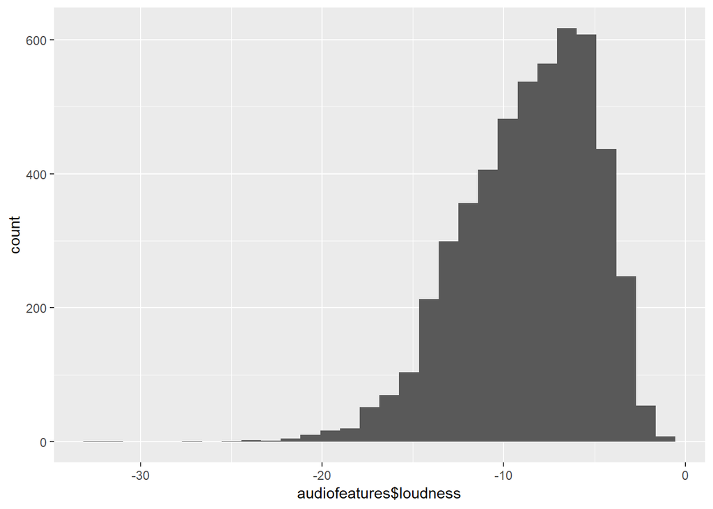

```r
library(ggplot2)
ggplot(data = audiofeatures, aes(audiofeatures$loudness)) + geom_histogram()
```

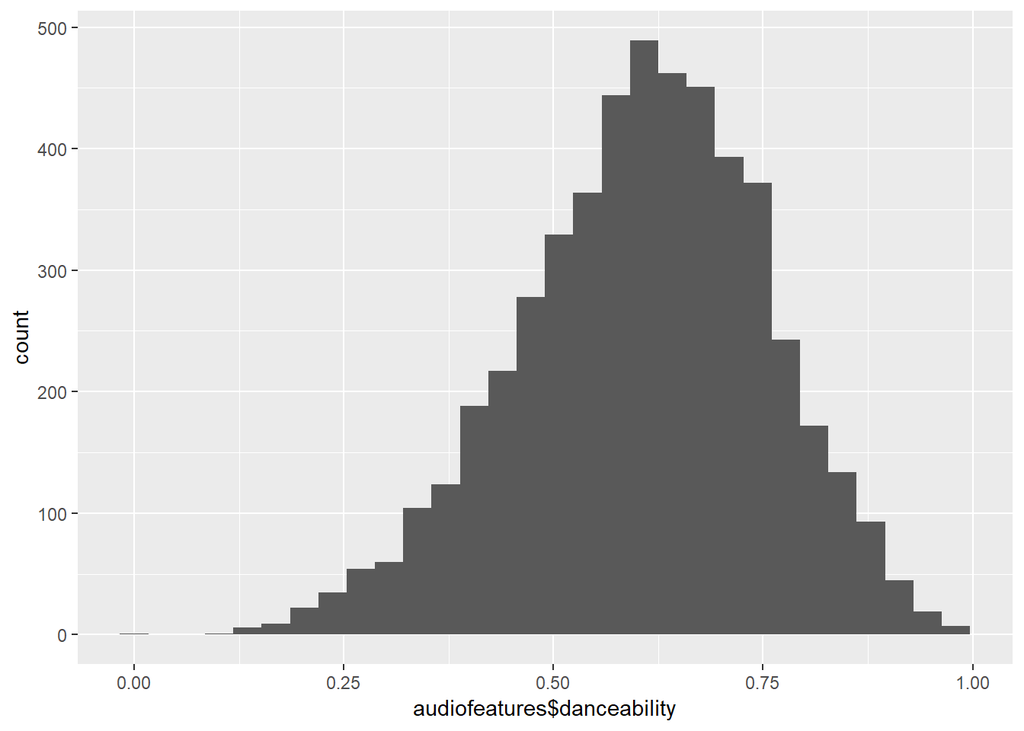

```r
ggplot(data = audiofeatures, aes(audiofeatures$danceability)) + geom_histogram()
```

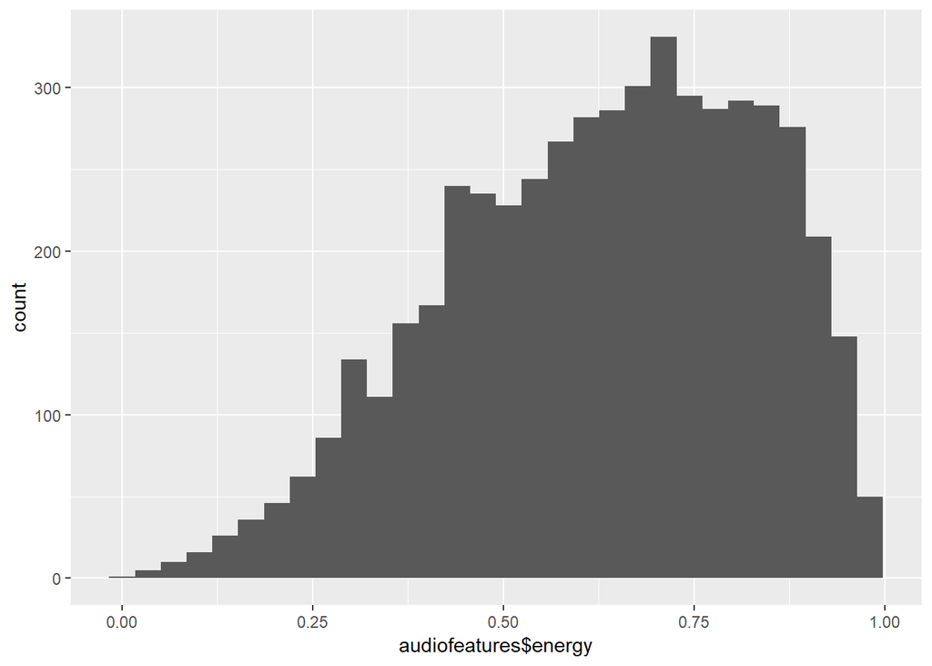

```r
ggplot(data = audiofeatures, aes(audiofeatures$energy)) + geom_histogram()
```

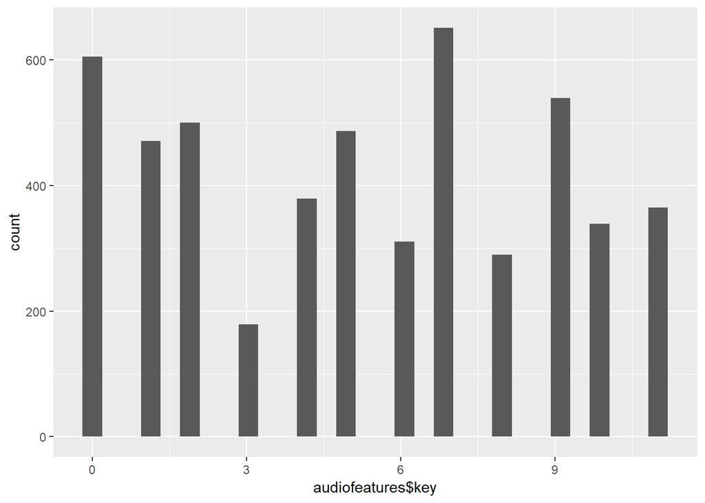

```r
ggplot(data = audiofeatures, aes(audiofeatures$key)) + geom_histogram()
```

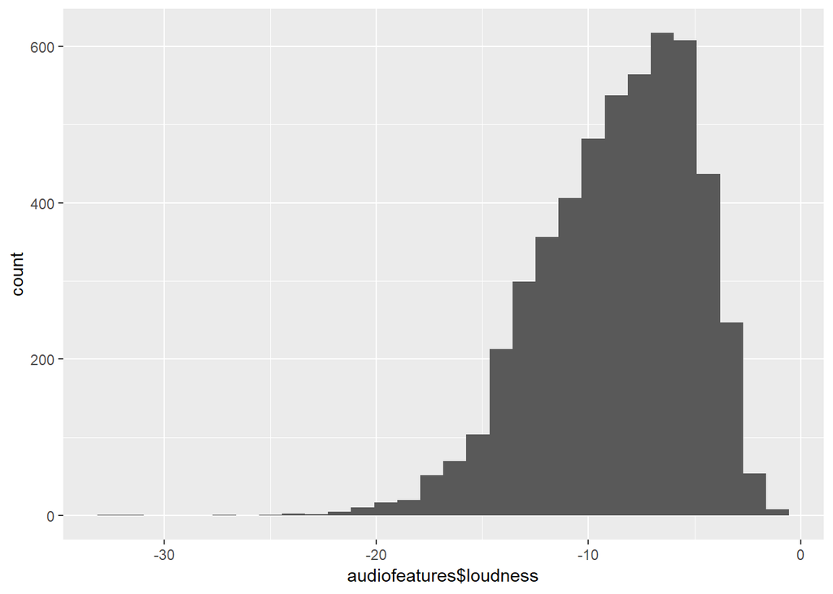

```r
ggplot(data = audiofeatures, aes(audiofeatures$loudness)) + geom_histogram()
```

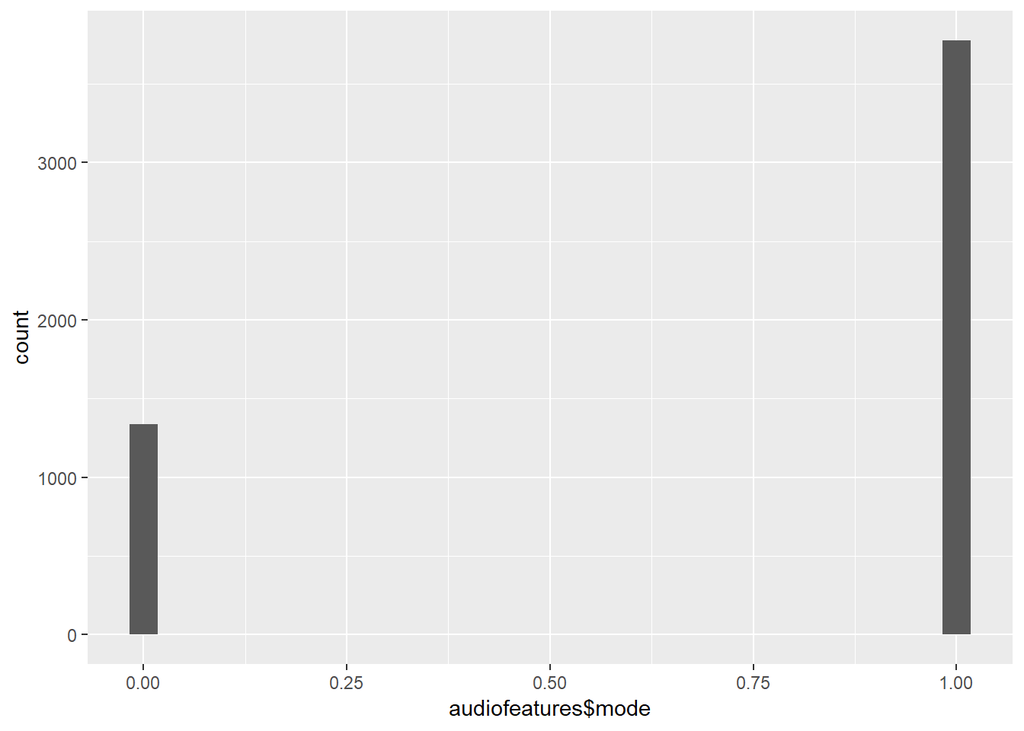

```r
ggplot(data = audiofeatures, aes(audiofeatures$mode)) + geom_histogram()
```

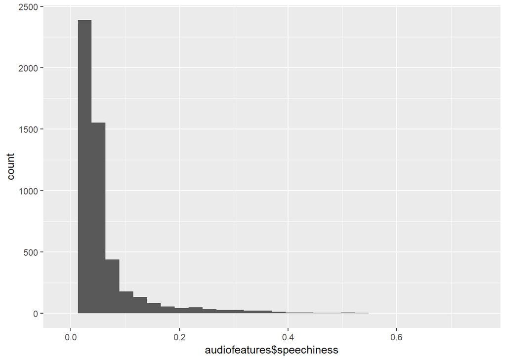

```r
ggplot(data = audiofeatures, aes(audiofeatures$speechiness)) + geom_histogram()
```

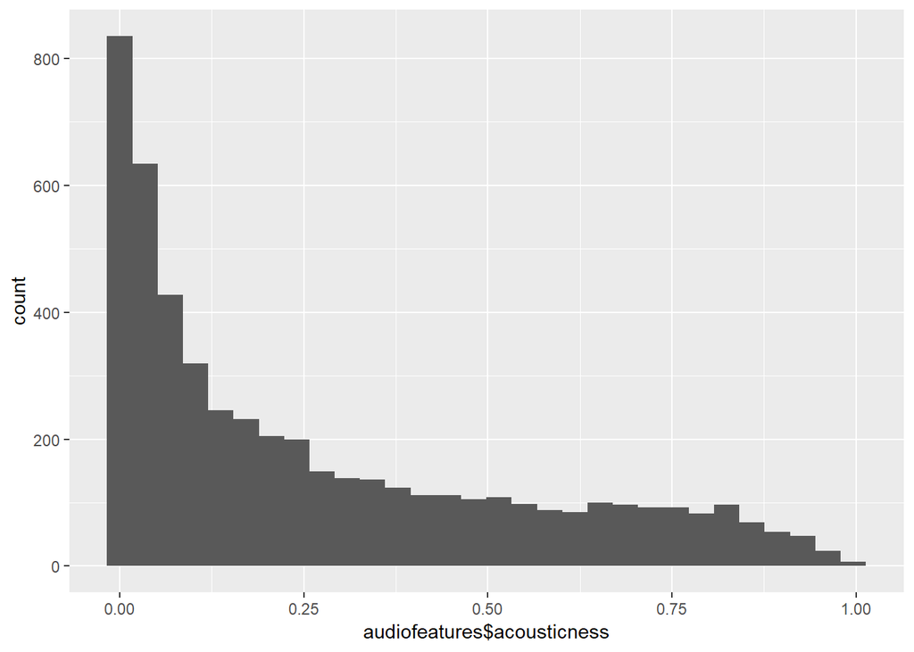

```r
ggplot(data = audiofeatures, aes(audiofeatures$acousticness)) + geom_histogram()
```

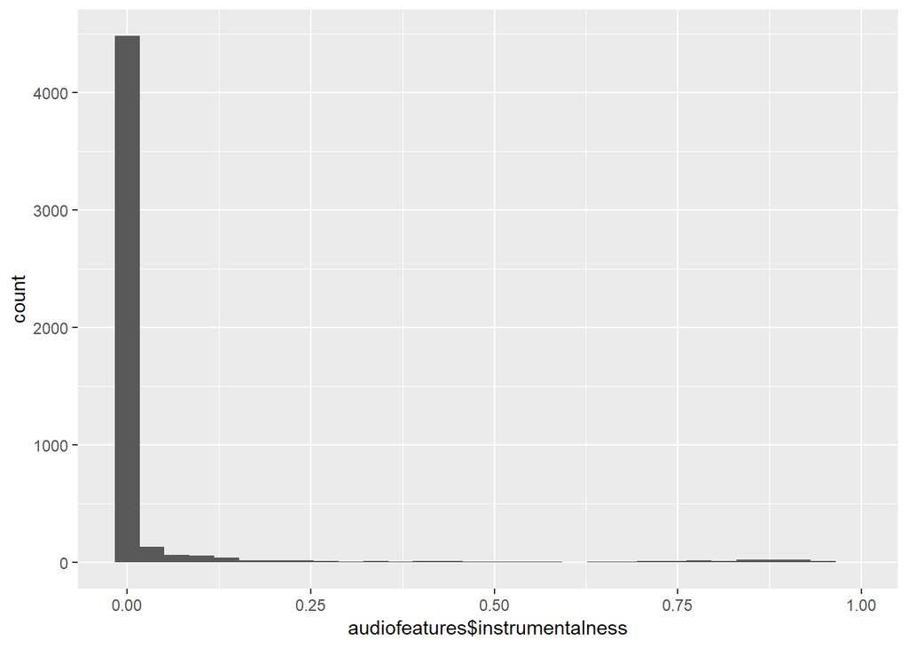

```r
ggplot(data = audiofeatures, aes(audiofeatures$instrumentalness)) + geom_histogram()
```

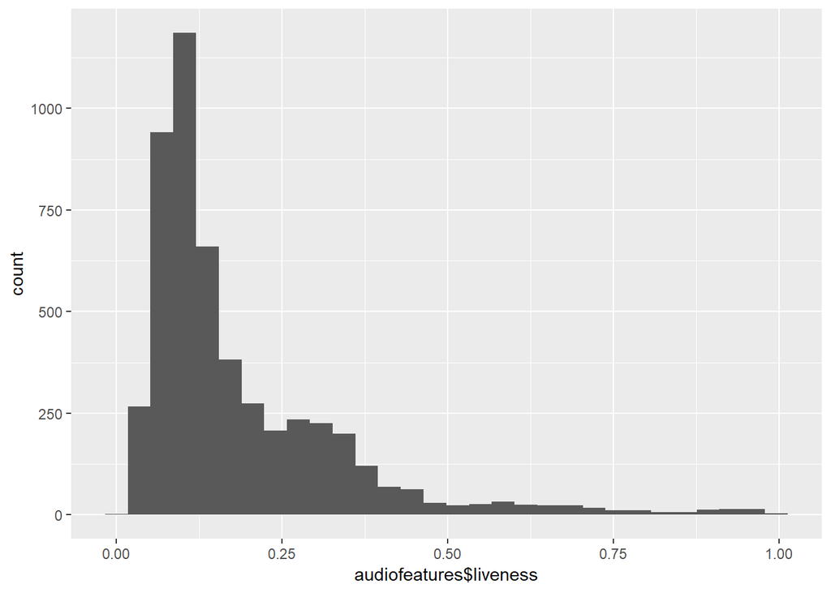

```r
ggplot(data = audiofeatures, aes(audiofeatures$liveness)) + geom_histogram()
```

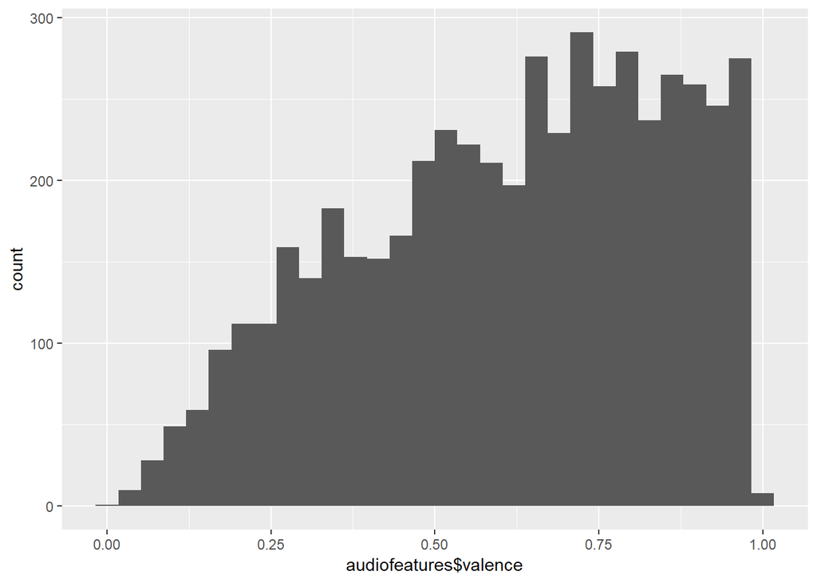

```r
ggplot(data = audiofeatures, aes(audiofeatures$valence)) + geom_histogram()
```

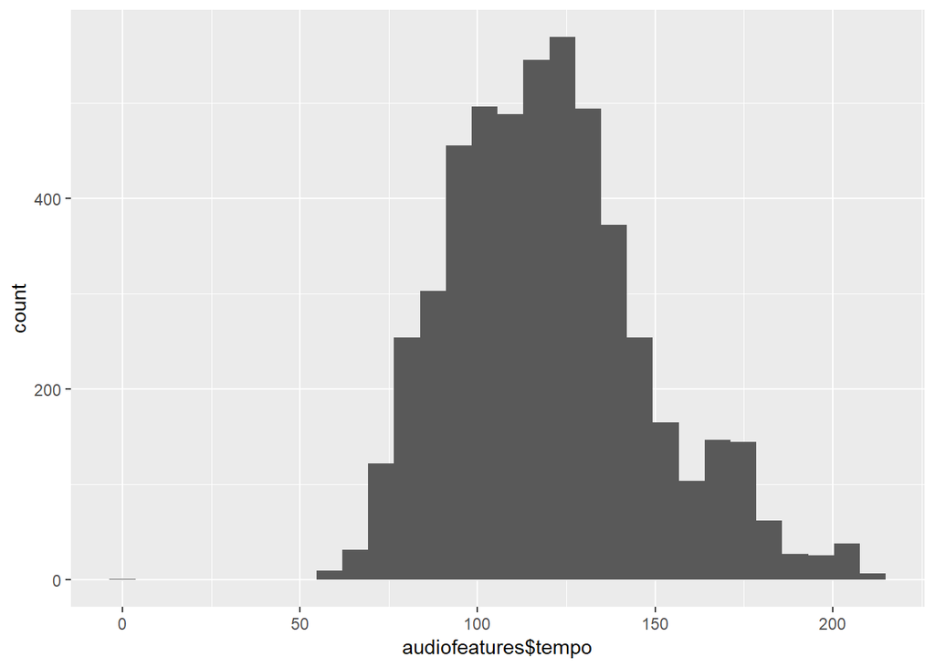

```r
ggplot(data = audiofeatures, aes(audiofeatures$tempo)) + geom_histogram()
```

```r
outliers <- function(col) {
  zscores <- scale(col)
  for (i in 1:length(col)) {
    if (abs(zscores[i]) > 3) {
      col[i] <- NA
    }
  }
  return(col)
}

audiofeatures$danceability <- outliers(audiofeatures$danceability)
audiofeatures$energy <- outliers(audiofeatures$energy)
audiofeatures$key <- outliers(audiofeatures$key)
audiofeatures$loudness <- outliers(audiofeatures$loudness)
audiofeatures$mode <- outliers(audiofeatures$mode)
audiofeatures$speechiness <- outliers(audiofeatures$speechiness)
audiofeatures$acousticness <- outliers(audiofeatures$acousticness)
audiofeatures$instrumentalness <- outliers(audiofeatures$instrumentalness)
audiofeatures$liveness <- outliers(audiofeatures$liveness)
audiofeatures$valence <- outliers(audiofeatures$valence)

audiofeatures <- audiofeatures[complete.cases(audiofeatures),]
```

DATA STORAGE & RETRIEVAL After removing outliers, write the two data frames that I created above to two tables in a SQL database. I call the two select * queries to ensure that the data was properly inserted into a table. Each table has the spotifyTrackId for each track, so I am able to join the tables together on this value. I use the sql MIN function to find the peak rank of each track on the charts in the data, and return that value along with the combination of all variables from both tables.

```r
library("RSQLite")

database <- dbConnect(SQLite(), dbname = "db.sqlite")

dbWriteTable(database, "audiofeatures", audiofeatures, overwrite = TRUE)
billboardData$chart_date <- as.character(billboardData$chart_date)
dbWriteTable(database, "billboard", billboardData, overwrite = TRUE)

dbGetQuery(database, statement = "SELECT * FROM audiofeatures")
```

| danceability | energy | key | loudness | mode | speechiness | acousticness | instrumentalness | liveness | valence | tempo | type | id | uri | track_href | analysis_url | duration_ms | time_signature |
| --- | --- | --- | --- | --- | --- | --- | --- | --- | --- | --- | --- | --- | --- | --- | --- | --- | --- |
| 0.543 | 0.3320 | 0 | -11.573 | 1 | 0.0317 | 6.69e-01 | 0.00e+00 | 0.1340 | 0.7950 | 154.999 | audio_features | 5ayybTSXNwcarDtxQKqvWX | spotify:track:5ayybTSXNwcarDtxQKqvWX | https://api.spotify.com/v1/tracks/5ayybTSXNwcarDtxQKqvWX | https://api.spotify.com/v1/audio-analysis/5ayybTSXNwcarDtxQKqvWX | 153933 | 4 |
| 0.645 | 0.9430 | 0 | -1.526 | 1 | 0.0393 | 3.85e-01 | 0.00e+00 | 0.3700 | 0.9650 | 147.768 | audio_features | 40fD7ct05FvQHLdQTgJelG | spotify:track:40fD7ct05FvQHLdQTgJelG | https://api.spotify.com/v1/tracks/40fD7ct05FvQHLdQTgJelG | https://api.spotify.com/v1/audio-analysis/40fD7ct05FvQHLdQTgJelG | 131720 | 4 |
| 0.715 | 0.6690 | 7 | -9.491 | 1 | 0.1280 | 7.05e-01 | 7.32e-04 | 0.0440 | 0.9760 | 120.789 | audio_features | 7demHL0GXA6YmTNqw3Btz8 | spotify:track:7demHL0GXA6YmTNqw3Btz8 | https://api.spotify.com/v1/tracks/7demHL0GXA6YmTNqw3Btz8 | https://api.spotify.com/v1/audio-analysis/7demHL0GXA6YmTNqw3Btz8 | 113040 | 4 |
| 0.554 | 0.1890 | 4 | -14.277 | 1 | 0.0279 | 9.15e-01 | 1.37e-05 | 0.1320 | 0.2140 | 136.714 | audio_features | 2urRqmAFhjZKo8Z6sEGzEv | spotify:track:2urRqmAFhjZKo8Z6sEGzEv | https://api.spotify.com/v1/tracks/2urRqmAFhjZKo8Z6sEGzEv | https://api.spotify.com/v1/audio-analysis/2urRqmAFhjZKo8Z6sEGzEv | 165293 | 3 |
| 0.778 | 0.8140 | 6 | -8.970 | 1 | 0.1400 | 9.89e-02 | 8.07e-06 | 0.1800 | 0.9210 | 98.857 | audio_features | 4ToAe9XCKjFGin2Qfswwis | spotify:track:4ToAe9XCKjFGin2Qfswwis | https://api.spotify.com/v1/tracks/4ToAe9XCKjFGin2Qfswwis | https://api.spotify.com/v1/audio-analysis/4ToAe9XCKjFGin2Qfswwis | 154733 | 4 |
| 0.573 | 0.7550 | 8 | -7.172 | 1 | 0.0375 | 3.25e-01 | 1.02e-06 | 0.2760 | 0.9700 | 148.105 | audio_features | 1dE8huV910G5VBqhQMmYkJ | spotify:track:1dE8huV910G5VBqhQMmYkJ | https://api.spotify.com/v1/tracks/1dE8huV910G5VBqhQMmYkJ | https://api.spotify.com/v1/audio-analysis/1dE8huV910G5VBqhQMmYkJ | 124667 | 4 |
| 0.471 | 0.3380 | 7 | -12.349 | 1 | 0.0526 | 6.00e-01 | 1.84e-01 | 0.4690 | 0.3880 | 125.963 | audio_features | 7CNY0qxDaCk1qCP18Lr0hY | spotify:track:7CNY0qxDaCk1qCP18Lr0hY | https://api.spotify.com/v1/tracks/7CNY0qxDaCk1qCP18Lr0hY | https://api.spotify.com/v1/audio-analysis/7CNY0qxDaCk1qCP18Lr0hY | 149699 | 3 |
| 0.310 | 0.1220 | 3 | -16.230 | 1 | 0.0344 | 8.78e-01 | 1.82e-04 | 0.1220 | 0.3420 | 83.152 | audio_features | 3bOkX6Yz6Pe4NByWzuJY6G | spotify:track:3bOkX6Yz6Pe4NByWzuJY6G | https://api.spotify.com/v1/tracks/3bOkX6Yz6Pe4NByWzuJY6G | https://api.spotify.com/v1/audio-analysis/3bOkX6Yz6Pe4NByWzuJY6G | 162307 | 4 |
| 0.421 | 0.3560 | 9 | -6.889 | 1 | 0.0286 | 8.83e-01 | 0.00e+00 | 0.2880 | 0.5140 | 98.393 | audio_features | 0lLMgROgXxjjwtg0VDo4oJ | spotify:track:0lLMgROgXxjjwtg0VDo4oJ | https://api.spotify.com/v1/tracks/0lLMgROgXxjjwtg0VDo4oJ | https://api.spotify.com/v1/audio-analysis/0lLMgROgXxjjwtg0VDo4oJ | 133178 | 3 |
| 0.587 | 0.1840 | 4 | -10.737 | 1 | 0.0444 | 8.29e-01 | 1.66e-05 | 0.1160 | 0.5290 | 111.195 | audio_features | 7u07WDKGH6LQ0E8evYhrWY | spotify:track:7u07WDKGH6LQ0E8evYhrWY | https://api.spotify.com/v1/tracks/7u07WDKGH6LQ0E8evYhrWY | https://api.spotify.com/v1/audio-analysis/7u07WDKGH6LQ0E8evYhrWY | 143693 | 4 |

[output cut: 4603 more lines]

```r
dbGetQuery(database, statement = "SELECT * FROM billboard")
```

| track_title | track_artist | track_rank | spotifyTrackID | chart_date |
| --- | --- | --- | --- | --- |
| Poor Little Fool | Ricky Nelson | 1 | 5ayybTSXNwcarDtxQKqvWX | 1958-08-04 |
| Patricia | Perez Prado And His Orchestra | 2 | NA | 1958-08-04 |
| Splish Splash | Bobby Darin | 3 | 40fD7ct05FvQHLdQTgJelG | 1958-08-04 |
| Hard Headed Woman | Elvis Presley With The Jordanaires | 4 | NA | 1958-08-04 |
| When | Kalin Twins | 5 | 1BQOMZeYwzesvXANmRgrEp | 1958-08-04 |
| Rebel-'rouser | Duane Eddy His Twangy Guitar And The Rebels | 6 | NA | 1958-08-04 |
| Yakety Yak | The Coasters | 7 | 7demHL0GXA6YmTNqw3Btz8 | 1958-08-04 |
| My True Love | Jack Scott | 8 | 2urRqmAFhjZKo8Z6sEGzEv | 1958-08-04 |
| Willie And The Hand Jive | The Johnny Otis Show | 9 | 4ToAe9XCKjFGin2Qfswwis | 1958-08-04 |
| Fever | Peggy Lee | 10 | 6eCsRg7OBi1zT2CEKKyoXN | 1958-08-04 |

[output cut: 6090 more lines]

```r
data <- dbGetQuery(database, "SELECT MIN(billboard.track_rank) as peak_rank, * FROM audiofeatures LEFT JOIN billboard ON billboard.spotifyTrackID = audiofeatures.id GROUP BY billboard.spotifyTrackID")
```

Here, I plot the data I retreive from my database above. This allows me to see correlations between the two different tables and how the data changes over time. I plot each of the audio features against the dates of the songs feature on the Billboard charts, which allows me to visualize changes in these features over the last 60 years. In general, these graphs show that music is getting louder, more danceable, more energetic, and less acoustic.

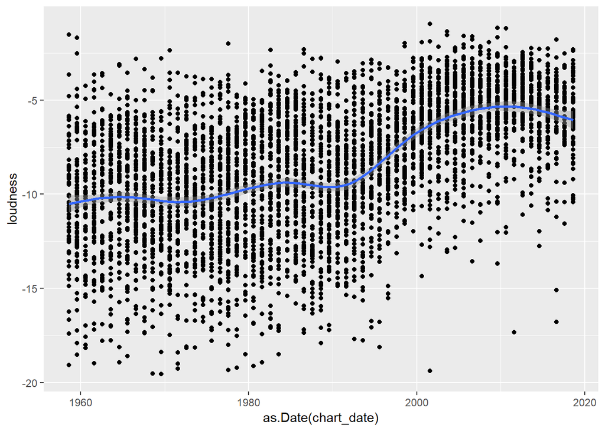

```r
ggplot(data = data, aes(x = as.Date(chart_date), y = loudness)) + geom_point() + geom_smooth()
```

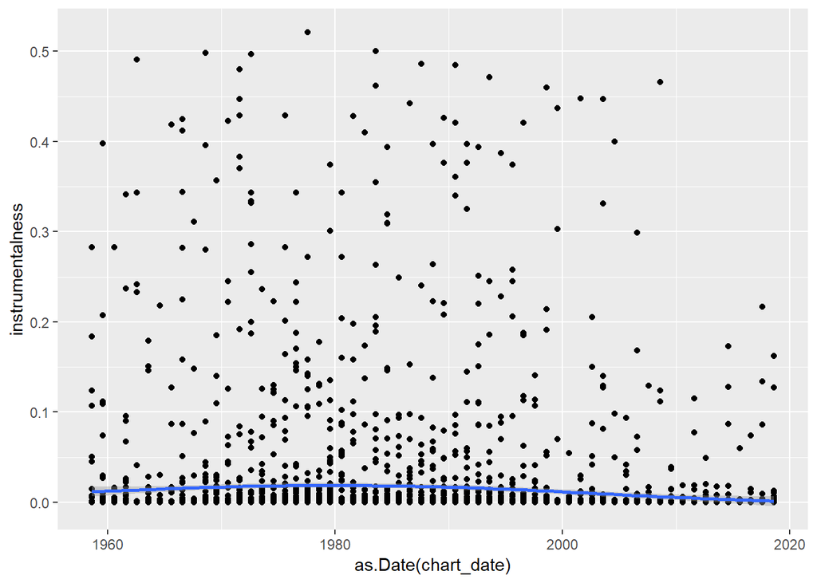

```r
ggplot(data = data, aes(x = as.Date(chart_date), y = instrumentalness)) + geom_point() + geom_smooth()
```

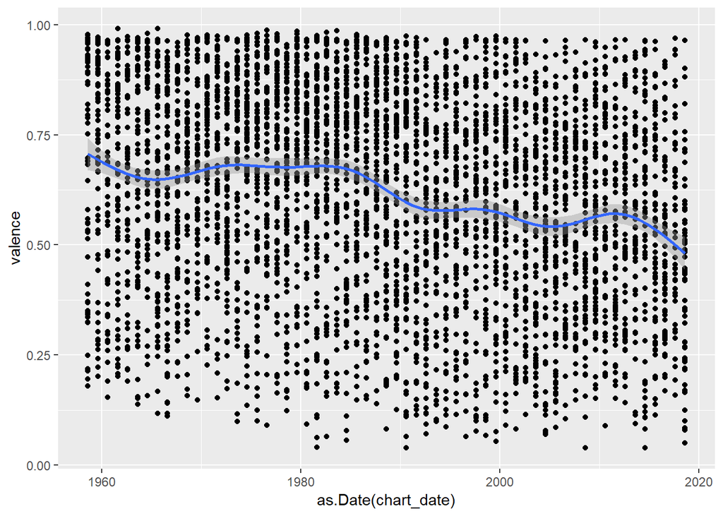

```r
ggplot(data = data, aes(x = as.Date(chart_date), y = valence)) + geom_point() + geom_smooth()
```

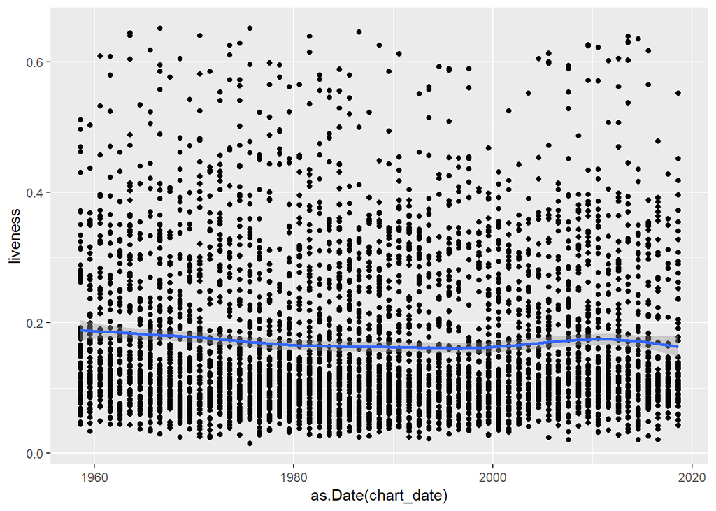

```r
ggplot(data = data, aes(x = as.Date(chart_date), y = liveness)) + geom_point() + geom_smooth()
```

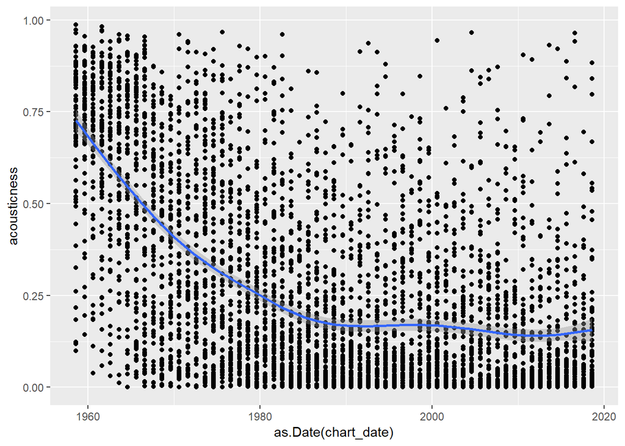

```r
ggplot(data = data, aes(x = as.Date(chart_date), y = acousticness)) + geom_point() + geom_smooth()
```

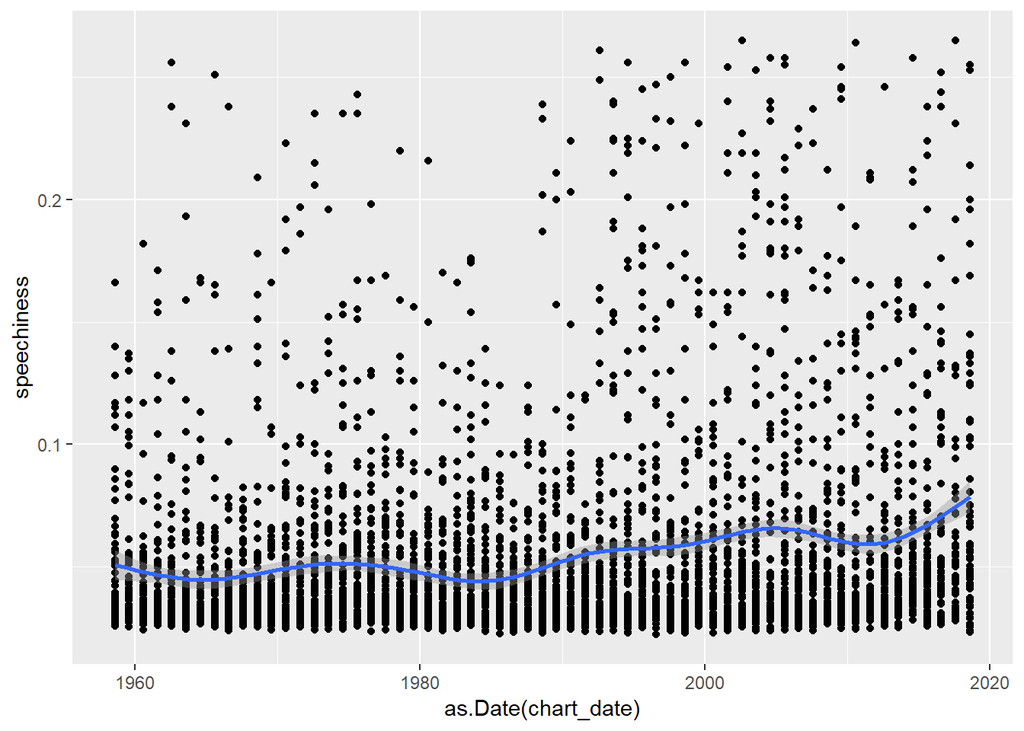

```r
ggplot(data = data, aes(x = as.Date(chart_date), y = speechiness)) + geom_point() + geom_smooth()
```

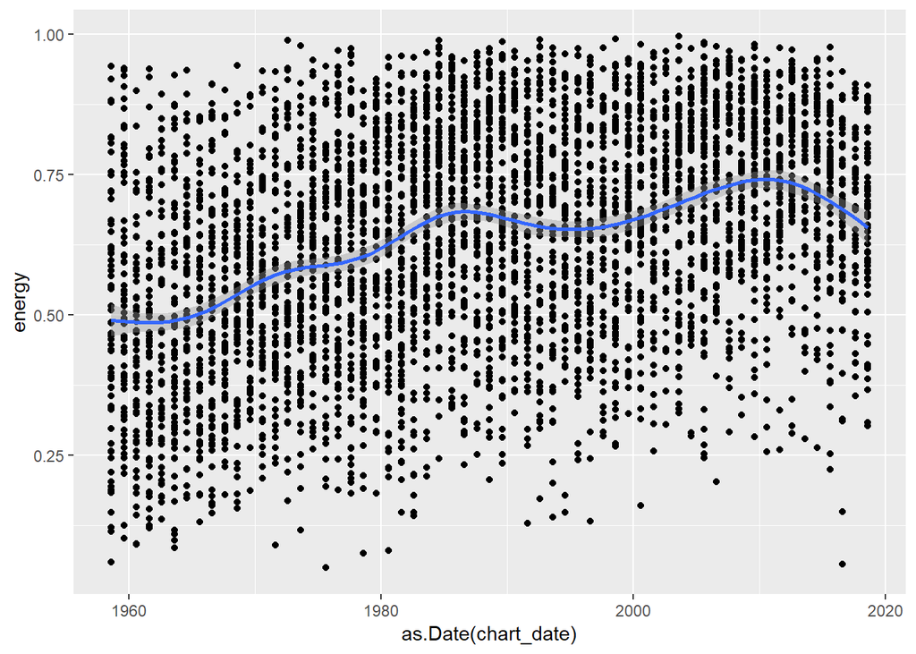

```r
ggplot(data = data, aes(x = as.Date(chart_date), y = energy)) + geom_point() + geom_smooth()
```

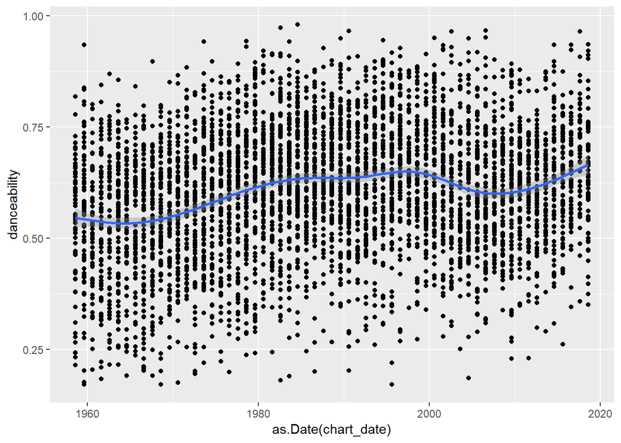

```r
ggplot(data = data, aes(x = as.Date(chart_date), y = danceability)) + geom_point() + geom_smooth()
```

```r
library(caTools)
splitVector <- sample.split(data$track_title, SplitRatio = .7)
train <- data[splitVector, ]
test <- data[!splitVector, ]

model <- lm(formula = peak_rank ~ danceability + energy + key + loudness + mode + speechiness + acousticness + instrumentalness + liveness + valence + tempo, data = train)

ideal.model <- step(model, direction = "backward")
```

```
## Start:  AIC=21592.14
## peak_rank ~ danceability + energy + key + loudness + mode + speechiness +
##     acousticness + instrumentalness + liveness + valence + tempo
##
##                    Df Sum of Sq     RSS   AIC
## - acousticness      1      19.5 2691421 21590
## - loudness          1     323.5 2691725 21591
## - instrumentalness  1     430.8 2691832 21591
## - tempo             1    1374.1 2692775 21592
## - energy            1    1562.5 2692964 21592
## - danceability      1    1574.7 2692976 21592
## - mode              1    1645.8 2693047 21592
## - key               1    1680.2 2693081 21592
## <none>                          2691401 21592
## - valence           1    2285.3 2693686 21593
## - speechiness       1    3260.9 2694662 21594
## - liveness          1    4066.1 2695467 21595
##
## Step:  AIC=21590.16
## peak_rank ~ danceability + energy + key + loudness + mode + speechiness +
##     instrumentalness + liveness + valence + tempo
##
##                    Df Sum of Sq     RSS   AIC
## - loudness          1     340.2 2691761 21589
## - instrumentalness  1     441.1 2691862 21589
## - tempo             1    1417.2 2692838 21590
## - danceability      1    1592.0 2693013 21590
## - mode              1    1628.9 2693050 21590
## - key               1    1677.5 2693098 21590
## <none>                          2691421 21590
## - energy            1    2264.5 2693685 21591
## - valence           1    2505.3 2693926 21591
## - speechiness       1    3260.6 2694681 21592
## - liveness          1    4047.9 2695468 21593
##
## Step:  AIC=21588.56
## peak_rank ~ danceability + energy + key + mode + speechiness +
##     instrumentalness + liveness + valence + tempo
##
##                    Df Sum of Sq     RSS   AIC
```

[output cut: 68 more lines]

```
##                Df Sum of Sq     RSS   AIC
## - energy        1    1638.8 2700004 21586
## <none>                      2698365 21586
## - speechiness   1    2697.0 2701062 21588
## - liveness      1    3452.4 2701817 21589
## - danceability  1    7153.2 2705518 21593
##
## Step:  AIC=21586.36
## peak_rank ~ danceability + speechiness + liveness
##
##                Df Sum of Sq     RSS   AIC
## <none>                      2700004 21586
## - speechiness   1    2199.2 2702203 21587
## - liveness      1    4030.8 2704034 21589
## - danceability  1    6387.5 2706391 21592
```

```r
test$peak_rank_prediction <- predict(ideal.model, newdata = test, type = "response")

accurateCount <- 0
for (i in 1:nrow(test)) {
  if (round(test$peak_rank_prediction[i]) == test$peak_rank[i]
      || round(test$peak_rank_prediction[i]) - 1 == test$peak_rank[i]
      || round(test$peak_rank_prediction[i]) + 1 == test$peak_rank[i]) {
    accurateCount <- accurateCount + 1
  }
}
print(accurateCount/nrow(test))
```

```
## [1] 0.0407866
```

Here, I construct a logistic regression model to try to predict the likelihood that a song breaks into the top 50 of the Billboard Hot 100.

```r
splitVector2 <- sample.split(data$track_title, SplitRatio = .7)
train2 <- data[splitVector2,]
test2 <- data[!splitVector2,]

top50 <- c()
for (i in 1:nrow(train2)) {
  if (train2$peak_rank[i] <= 50) {
    top50 <- c(top50, TRUE)
  } else {
    top50 <- c(top50, FALSE)
  }
}
train2$top50 <- top50

top50Model <- glm(formula = top50 ~ danceability + energy + key + loudness + mode + speechiness + acousticness + instrumentalness + liveness + valence + tempo, family = "binomial", data = train2)
optimal <- step(top50Model, direction = "backward")
```

```
## Start:  AIC=4440.58
## top50 ~ danceability + energy + key + loudness + mode + speechiness +
##     acousticness + instrumentalness + liveness + valence + tempo
##
##                    Df Deviance    AIC
## - tempo             1   4416.6 4438.6
## - acousticness      1   4416.6 4438.6
## - speechiness       1   4416.7 4438.7
## - liveness          1   4417.1 4439.1
## - mode              1   4417.1 4439.1
## - loudness          1   4417.3 4439.3
## - instrumentalness  1   4417.7 4439.7
## - valence           1   4418.1 4440.1
## - energy            1   4418.3 4440.3
## <none>                  4416.6 4440.6
## - key               1   4418.9 4440.9
## - danceability      1   4421.7 4443.7
##
## Step:  AIC=4438.63
## top50 ~ danceability + energy + key + loudness + mode + speechiness +
##     acousticness + instrumentalness + liveness + valence
##
##                    Df Deviance    AIC
## - acousticness      1   4416.7 4436.7
## - speechiness       1   4416.8 4436.8
## - liveness          1   4417.2 4437.2
## - mode              1   4417.2 4437.2
## - loudness          1   4417.3 4437.3
## - instrumentalness  1   4417.8 4437.8
## - valence           1   4418.3 4438.3
## - energy            1   4418.3 4438.3
## <none>                  4416.6 4438.6
## - key               1   4419.0 4439.0
## - danceability      1   4421.9 4441.9
##
## Step:  AIC=4436.7
## top50 ~ danceability + energy + key + loudness + mode + speechiness +
##     instrumentalness + liveness + valence
##
##                    Df Deviance    AIC
```

[output cut: 75 more lines]

```
## top50 ~ danceability + key + instrumentalness
##
##                    Df Deviance    AIC
## - instrumentalness  1   4421.8 4427.8
## <none>                  4420.6 4428.6
## - key               1   4422.6 4428.6
## - danceability      1   4432.7 4438.7
##
## Step:  AIC=4427.84
## top50 ~ danceability + key
##
##                Df Deviance    AIC
## <none>              4421.8 4427.8
## - key           1   4423.9 4427.9
## - danceability  1   4433.8 4437.8
```

```r
top50 <- c()
for (i in 1:nrow(test2)) {
  if (test2$peak_rank[i] <= 50) {
    top50 <- c(top50, TRUE)
  } else {
    top50 <- c(top50, FALSE)
  }
}
test2$top50 <- top50

predictions <- predict(object = optimal, newdata = test2, type = "response")
for (i in 1:length(predictions)) {
  if (predictions[i] > .5) {
    predictions[i] = TRUE
  } else {
    predictions[i] = FALSE
  }
}
test2$top50predictions <- predictions


accurate <- 0
for (i in 1:nrow(test2)) {
  if (test2$top50predictions[i] == test2$top50[i]) {
    accurate <- accurate + 1
  }
}
print(accurate/nrow(test2))
```

```
## [1] 0.5433358
```